# Assignment 3 Quarto

Author

Jack Swaisgood

## Are Larger Lineman Ranked Higher than Smaller Lineman?

Size is a very important part of playing “in the trenches” in modern college football. I will look at player’s weight, and will try to find out if the larger kids are generally ranked higher.

I will gauge how highly ranked these players are by their number of stars, as players with more stars are the more highly touted recruits. 4 and 5 star players are called “blue-chip recruits”, as they are generally who college football powerhouses go after. I will need to filter in Centers, Guards, Offensive tackles and Defensive tackles, as these are the players I am seeking information about.

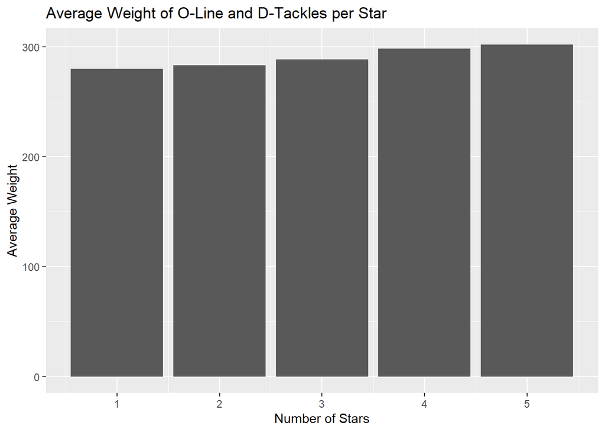

```r
cfbrec %>%
  filter(position %in% c('OC', 'OG', 'OT', 'DT')) %>%
  ggplot(aes(x = stars, y = weight)) +
  geom_bar(stat = "summary", fun = mean) +
  labs(title = "Average Weight of O-Line and D-Tackles per Star",
       x = "Number of Stars",
       y = "Average Weight")
```

I found that there is a slightly positive relationship between weight and number of stars that recruits have. An interesting feature that I didn’t expect was that these “blue-chip recruits” that I mentioned earlier are fairly clearly larger than the rest of the recruits. To answer my question: yes, larger players “in the trenches” tend to be higher ranked than smaller ones.